# Ch 13 exercises

These exercises will push you a bit to fit GLMs to various kinds of data. You’ll need to pay attention to the nature of the predictors and think about the response variables and their likely distributions.

### A

The data are available on [Dryad](https://doi.org/10.%205061/dryad.fqz612jpq), and you’ll want the Excel file Fig3.xls, and within it, the sheet labelled 2008. Before using it in analysis, you’ll need to tidy up the first few rows. Alternatively, here’s a simplified version, with three columns, treatment, moth, and parasitoid.

#### What distribution would you expect the response variable *parasitoid* to follow?

> First assumption might be Poisson, as counts that are relatively small.

#### Import the data and check the properties of the response variable.

Hint: Try graphical presentation (possibly including a transformation) and look at summary statistics

```r
#Import uefune data file (uefune.csv)
uefune <- read.csv("data/uefunex.csv")
head(uefune,10)
```

|  | treatment | moth | parasitoid |
| --- | --- | --- | --- |
| 1 | treated | 0 | 0 |
| 2 | treated | 0 | 0 |
| 3 | treated | 0 | 0 |
| 4 | treated | 0 | 0 |
| 5 | treated | 0 | 0 |
| 6 | treated | 0 | 0 |
| 7 | treated | 0 | 1 |
| 8 | treated | 0 | 0 |
| 9 | treated | 0 | 0 |
| 10 | treated | 0 | 0 |

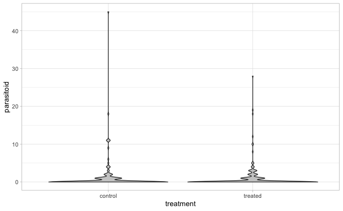

```r
#Check parasitoid distribution by treatment
ggplot(uefune,aes(treatment, parasitoid))+
  geom_violin(fill='grey80')+ theme_light()
```

```r
# Get summary statistics
summarySE(data=uefune, measurevar="parasitoid", groupvars=c("treatment"))
```

| treatment | N | parasitoid | sd | se | ci |
| --- | --- | --- | --- | --- | --- |
| control | 177 | 1.102 | 4.06 | 0.305 | 0.603 |
| treated | 242 | 0.938 | 2.87 | 0.185 | 0.364 |

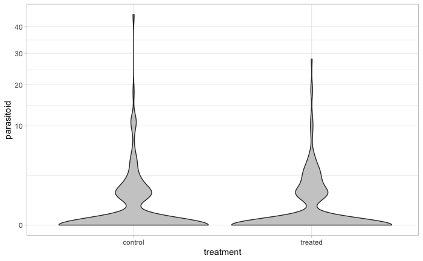

```r
#Try square root transform
ggplot(uefune,aes(treatment, parasitoid))+
  geom_violin(fill='grey80')+  scale_y_sqrt()+  theme_light()
```

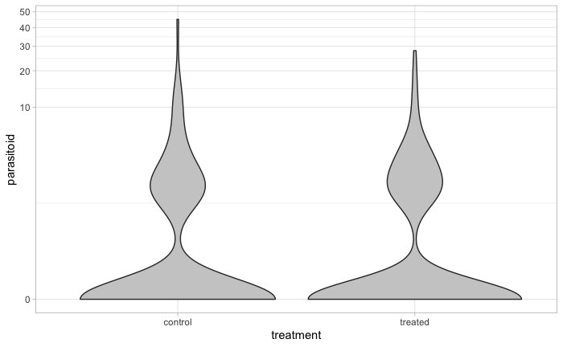

```r
#Could even try 4th root
ggplot(uefune,aes(treatment, parasitoid))+
  geom_violin(fill='grey80') +  scale_y_continuous(trans=power_trans(1/4)) + theme_light()
```

** What do you conclude about the response variable?**

> Strongly skewed, with lots of zeros. Variance >> mean

> Transformations reduce skew, but still do not resemble a normal distribution.

> Possible overdispersion

#### Fit a poisson glm and interpret the results

You should have decided that the data are too skewed to fit a linear model assuming a normal distribution, and a poisson is a strong candidate.

```r
uefune.glm <- glm(parasitoid~moth+treatment+moth*treatment, family=poisson, data=uefune)
summary(uefune.glm)
```

```
Call:
glm(formula = parasitoid ~ moth + treatment + moth * treatment,
    family = poisson, data = uefune)

Deviance Residuals:
   Min      1Q  Median      3Q     Max
-4.566  -1.217  -1.137   0.074  15.532

Coefficients:
                      Estimate Std. Error z value Pr(>|z|)
(Intercept)            -0.3011     0.0880   -3.42  0.00063 ***
moth                    0.2265     0.0143   15.80  < 2e-16 ***
treatmenttreated       -0.1362     0.1190   -1.14  0.25246
moth:treatmenttreated   0.1847     0.0260    7.11  1.2e-12 ***
---
Signif. codes:  0 ‘***’ 0.001 ‘**’ 0.01 ‘*’ 0.05 ‘.’ 0.1 ‘ ’ 1

(Dispersion parameter for poisson family taken to be 1)

    Null deviance: 1600.0  on 418  degrees of freedom
Residual deviance: 1220.5  on 415  degrees of freedom
AIC: 1551

Number of Fisher Scoring iterations: 6
```

```r
anova(uefune.glm, test="LRT")
```

```
Analysis of Deviance Table

Model: poisson, link: log

Response: parasitoid

Terms added sequentially (first to last)

               Df Deviance Resid. Df Resid. Dev Pr(>Chi)
NULL                             418       1600
moth            1      328       417       1272  < 2e-16 ***
treatment       1        6       416       1266    0.016 *
moth:treatment  1       46       415       1220  1.4e-11 ***
---
Signif. codes:  0 ‘***’ 0.001 ‘**’ 0.01 ‘*’ 0.05 ‘.’ 0.1 ‘ ’ 1
```

```r
AICc(uefune.glm)
```

```
[1] 1551
```

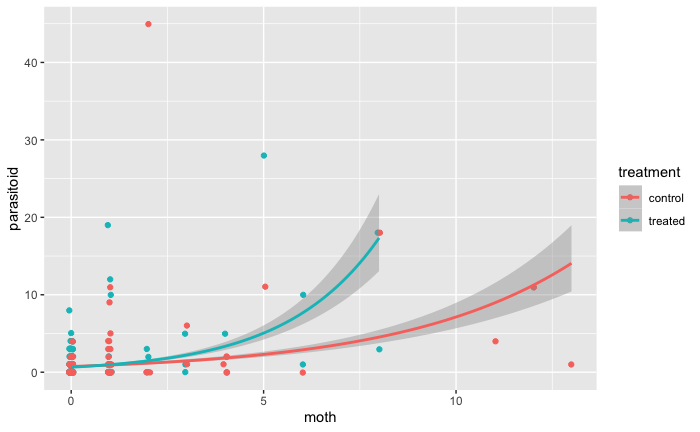

```r
ggplot(data = uefune, aes(x = moth, y = parasitoid, line=treatment, color=treatment)) +
  geom_jitter(stat = "identity", width = 0.05, height = 0.05) + geom_smooth(method = 'glm', method.args = list(family = 'poisson'))
```

> Strong interaction between the treatment and moth numbers

#### Extension question

A look at the means and standard deviations suggests that the variance was much larger than the mean, suggesting some overdispersion. Let’s check for it, and see if we should be concerned

Hint: here’s an R code chunk to do that:

presid <- resid(uefune.glm, type=“pearson”)  
ssize <- nrow(uefune1)  
params <- length(coef(uefune.glm))  
disp <- sum(presid^2)/(ssize-params)  
disp

```r
#Check overdispersion by calculating dispersion statistic
presid <- resid(uefune.glm, type="pearson")
ssize <- nrow(uefune)
params <- length(coef(uefune.glm))
disp <- sum(presid^2)/(ssize-params)
disp
```

```
[1] 7.71
```

```r
#Check by fitting quasi-Poisson


uefune1.glm <- glm(parasitoid~moth+treatment+moth*treatment, family=quasipoisson, data=uefune)
summary(uefune1.glm)
```

```
Call:
glm(formula = parasitoid ~ moth + treatment + moth * treatment,
    family = quasipoisson, data = uefune)

Deviance Residuals:
   Min      1Q  Median      3Q     Max
-4.566  -1.217  -1.137   0.074  15.532

Coefficients:
                      Estimate Std. Error t value Pr(>|t|)
(Intercept)            -0.3011     0.2445   -1.23    0.219
moth                    0.2265     0.0398    5.69  2.4e-08 ***
treatmenttreated       -0.1362     0.3305   -0.41    0.681
moth:treatmenttreated   0.1847     0.0721    2.56    0.011 *
---
Signif. codes:  0 ‘***’ 0.001 ‘**’ 0.01 ‘*’ 0.05 ‘.’ 0.1 ‘ ’ 1

(Dispersion parameter for quasipoisson family taken to be 7.71)

    Null deviance: 1600.0  on 418  degrees of freedom
Residual deviance: 1220.5  on 415  degrees of freedom
AIC: NA

Number of Fisher Scoring iterations: 6
```

```r
anova(uefune1.glm, test="LRT")
```

```
Analysis of Deviance Table

Model: quasipoisson, link: log

Response: parasitoid

Terms added sequentially (first to last)

               Df Deviance Resid. Df Resid. Dev Pr(>Chi)
NULL                             418       1600
moth            1      328       417       1272  6.9e-11 ***
treatment       1        6       416       1266    0.387
moth:treatment  1       46       415       1220    0.015 *
---
Signif. codes:  0 ‘***’ 0.001 ‘**’ 0.01 ‘*’ 0.05 ‘.’ 0.1 ‘ ’ 1
```

```r
AICc(uefune1.glm)
```

```
[1] NA
```

**Conclusions?**

> Residual deviance >> residual df, and dispersion statistic large, so overdispersed

> Fit negative binomial

```r
uefune.nb <- glm.nb(parasitoid~moth+treatment+moth*treatment, data=uefune)
uefune.nb$theta
```

```
[1] 0.263
```

```r
uefune.nb <- glm.convert(uefune.nb)
summary(uefune.nb)
```

```
Call:
stats::glm(formula = parasitoid ~ moth + treatment + moth * treatment,
    data = uefune, family = negative.binomial(theta = 0.263186708728143,
        link = log))

Deviance Residuals:
   Min      1Q  Median      3Q     Max
-1.659  -0.777  -0.740  -0.007   3.601

Coefficients:
                      Estimate Std. Error t value Pr(>|t|)
(Intercept)            -0.7326     0.2226   -3.29   0.0011 **
moth                    0.5445     0.0858    6.35  5.7e-10 ***
treatmenttreated        0.1632     0.2887    0.57   0.5721
moth:treatmenttreated   0.0400     0.1618    0.25   0.8049
---
Signif. codes:  0 ‘***’ 0.001 ‘**’ 0.01 ‘*’ 0.05 ‘.’ 0.1 ‘ ’ 1

(Dispersion parameter for Negative Binomial(0.263) family taken to be 1.38)

    Null deviance: 342.96  on 418  degrees of freedom
Residual deviance: 274.34  on 415  degrees of freedom
AIC: 927.8

Number of Fisher Scoring iterations: 1
```

```r
anova(uefune.nb, test="LRT")
```

```
Analysis of Deviance Table

Model: Negative Binomial(0.263), link: log

Response: parasitoid

Terms added sequentially (first to last)

               Df Deviance Resid. Df Resid. Dev Pr(>Chi)
NULL                             418        343
moth            1     67.9       417        275  2.2e-12 ***
treatment       1      0.6       416        274     0.49
moth:treatment  1      0.0       415        274     0.88
---
Signif. codes:  0 ‘***’ 0.001 ‘**’ 0.01 ‘*’ 0.05 ‘.’ 0.1 ‘ ’ 1
```

**How does your solution work?**

> Moth x treatment and treatment effects much weaker, and dominant feature is the effect of moth numbers

**For interest(!), you could also compare the results to the “old” way of transforming response variables closer to normality and fitting an OLS linear model**

Try linear with sqrt transform

```r
uefune1.lm <- lm(sqrt(parasitoid)~moth+treatment+moth*treatment, data=uefune)
summary(uefune1.lm)
```

```
Call:
lm(formula = sqrt(parasitoid) ~ moth + treatment + moth * treatment,
    data = uefune)

Residuals:
   Min     1Q Median     3Q    Max
-2.170 -0.345 -0.314  0.455  5.955

Coefficients:
                      Estimate Std. Error t value Pr(>|t|)
(Intercept)             0.3138     0.0628    5.00  8.5e-07 ***
moth                    0.2197     0.0287    7.65  1.4e-13 ***
treatmenttreated        0.0314     0.0819    0.38    0.702
moth:treatmenttreated   0.1421     0.0541    2.63    0.009 **
---
Signif. codes:  0 ‘***’ 0.001 ‘**’ 0.01 ‘*’ 0.05 ‘.’ 0.1 ‘ ’ 1

Residual standard error: 0.787 on 415 degrees of freedom
Multiple R-squared:  0.225, Adjusted R-squared:  0.22
F-statistic: 40.2 on 3 and 415 DF,  p-value: <2e-16
```

```r
anova(uefune1.lm)
```

```
Analysis of Variance Table

Response: sqrt(parasitoid)
                Df Sum Sq Mean Sq F value Pr(>F)
moth             1   69.6    69.6  112.45 <2e-16 ***
treatment        1    0.9     0.9    1.39  0.240
moth:treatment   1    4.3     4.3    6.89  0.009 **
Residuals      415  256.8     0.6
---
Signif. codes:  0 ‘***’ 0.001 ‘**’ 0.01 ‘*’ 0.05 ‘.’ 0.1 ‘ ’ 1
```

```r
AICc(uefune1.lm)
```

```
[1] 994
```

> Conclusions similar to the poisson regression

### B

The data were provided as an Excel file through [Dryad](https://datadryad.org/stash/dataset/doi:10.5061%2Fdryad.q5gh6), which needs a little tidying to use in R; two additional header rows, and some variable names quite long. Use the tidied caudill.csv file for convenience

```r
df <- read.csv("data/caudill.csv")
head(df,10)
```

|  | site | habitat | trapnights | individuals | specdens_small | rrapnights_camera | num_images | specdens_ml | totspecdens | canopy | basalarea | midstrata | lowstrata | groundcov | treecount | elevation | treerichness | treeheight | coffeeheight | X |
| --- | --- | --- | --- | --- | --- | --- | --- | --- | --- | --- | --- | --- | --- | --- | --- | --- | --- | --- | --- | --- |
| 1 | 1 | BF | 500 | 3 | 1 | 10 | 8 | 2 | 3 | 90.9 | 37.9 | 35.7 | 30.3 | 62.2 | 84 | 723 | 10 | 20.4 | 2.5 | NA |
| 2 | 2 | BF | 500 | 14 | 4 | 10 | 10 | 5 | 9 | 81.4 | 20.7 | 70.3 | 86.5 | 2.6 | 59 | 711 | 12 | 15.1 | 2.7 | NA |
| 3 | 3 | BF | 480 | 6 | 3 | 10 | 9 | 3 | 6 | 92.7 | 34.0 | 58.6 | 21.4 | 53.4 | 80 | 713 | 13 | 11.7 | 2.8 | NA |
| 4 | 4 | BF | 480 | 13 | 4 | 10 | 24 | 3 | 7 | 77.3 | 22.9 | 54.5 | 67.7 | 3.2 | 41 | 660 | 9 | 18.4 | 2.7 | NA |
| 5 | 5 | BF | 480 | 16 | 3 | 10 | 3 | 1 | 4 | 91.7 | 22.9 | 64.5 | 54.3 | 65.9 | 48 | 641 | 5 | 12.9 | 2.7 | NA |
| 6 | 6 | BF | 500 | 21 | 5 | 10 | 3 | 2 | 7 | 82.3 | 22.9 | 35.8 | 70.6 | 7.1 | 35 | 755 | 9 | 19.4 | 2.4 | NA |
| 7 | 7 | Forest | 500 | 6 | 2 | 10 | 5 | 2 | 4 | 89.0 | 12.0 | 76.8 | 53.8 | 28.4 | 171 | 487 | NA | NA | NA | NA |
| 8 | 8 | Forest | 500 | 16 | 3 | 10 | 5 | 2 | 5 | 96.6 | 18.4 | 18.3 | 65.1 | 9.4 | 112 | 496 | NA | NA | NA | NA |
| 9 | 9 | Forest | 340 | 2 | 2 | 10 | 12 | 1 | 3 | 89.6 | 38.6 | 66.7 | 51.7 | 24.3 | 35 | 650 | NA | NA | NA | NA |
| 10 | 10 | Forest | 480 | 4 | 1 | 10 | 5 | 3 | 4 | 96.0 | 26.8 | 44.6 | 39.2 | 17.8 | 203 | 667 | NA | NA | NA | NA |

```r
#Forest habitat has no coffee trees, and low tree richness, so habitat variables not all present. Create subset of this data file
df2<-filter(df, habitat != 'Forest')
```

Potential explanatory habitat variables are

- % canopy cover,
- % mid-strata vegetation,
- % lower strata vegetation,
- % ground cover,
- tree basal area (m2/ha),
- tree density (number of trees/m2),
- tree richness,
- tree height (m), and
- coffee height (m)

Caudill & Rice examined three response variables, Small Mammal “species density”, which was the number of small mammal species recorded, medium-large density, and total species density, which combined small and med-large.

1. Import the data file and have a look at it.

Look at the three response variables. What kind of distribution is most likely for them?

Would you analyse all three response variables? Why?

> Check whether they were correlated. Could just do 2/3

```r
cor(df2[c('specdens_small', 'specdens_ml', 'totspecdens')])
```

```
               specdens_small specdens_ml totspecdens
specdens_small          1.000       0.159       0.710
specdens_ml             0.159       1.000       0.809
totspecdens             0.710       0.809       1.000
```

> Small and Med-L mammal richness isn’t correlated strongly, but both are correlated with the total. Would probably just do small and ML separately
2. What checks would you do for the habitat predictor variables, and what do you conclude from those checks?

> Checks for correlations among predictors. Remember from earlier chapters that an easy way to check VIFs etc, is just to fit an OLS linear model for one of the predictors; doesn’t need to be GLM

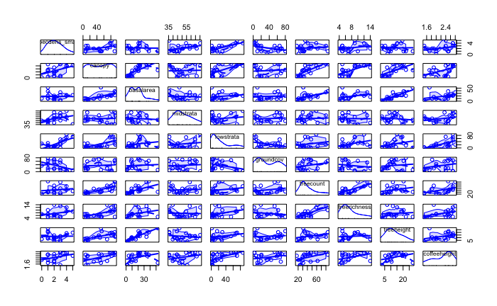

```r
scatterplotMatrix(data=df2, ~ specdens_small + canopy + basalarea + midstrata + lowstrata + groundcov + treecount + treerichness + treeheight + coffeeheight)
```

```r
cor(df2[,c('canopy', 'basalarea', 'midstrata', 'lowstrata', 'groundcov', 'treecount', 'treerichness', 'treeheight', 'coffeeheight')])
```

```
             canopy basalarea midstrata lowstrata groundcov treecount treerichness treeheight coffeeheight
canopy       1.0000    0.6798    0.0313     0.612    0.0943    0.7585       0.5942     0.5944        0.563
basalarea    0.6798    1.0000   -0.0898     0.200    0.0710    0.5368       0.2981     0.8541        0.322
midstrata    0.0313   -0.0898    1.0000     0.181    0.0857    0.0649      -0.0255    -0.1536        0.280
lowstrata    0.6124    0.2001    0.1806     1.000   -0.3347    0.2349       0.3861     0.3156        0.581
groundcov    0.0943    0.0710    0.0857    -0.335    1.0000    0.2642      -0.1810     0.1194        0.269
treecount    0.7585    0.5368    0.0649     0.235    0.2642    1.0000       0.7466     0.2858        0.445
treerichness 0.5942    0.2981   -0.0255     0.386   -0.1810    0.7466       1.0000     0.0875        0.377
treeheight   0.5944    0.8541   -0.1536     0.316    0.1194    0.2858       0.0875     1.0000        0.365
coffeeheight 0.5626    0.3215    0.2801     0.581    0.2694    0.4445       0.3772     0.3652        1.000
```

```r
vif(lm(data=df2, specdens_small ~ canopy + basalarea + midstrata + lowstrata + groundcov + treecount + treerichness + treeheight + coffeeheight))
```

```
      canopy    basalarea    midstrata    lowstrata    groundcov    treecount treerichness   treeheight coffeeheight
        8.05         9.34         1.33         5.94         3.73         7.57         4.40         7.39         3.04
```

> Some concerning correlations, largely among the tree variables - canopy cover, basal area, tree count and treeheight. Very strong correlation between basal area and tree height and strong r>.7 relationships between tree count & canopy cover, tree richness and tree count. This suggests that we don’t need tree height and basal area, and we could drop one of tree count, canopy cover and tree richness. Basal area has the highest VIF, so probably drop that one. Of the other three, we’d lean towards dropping tree count, as the other two seem to convey additional habitat information.
3. The authors showed some differences in mammal diversity between habitat types, but for their regression analysis they ignored habitat. Are there any additional checks you’d do before proceeding.

> Look for differences between habitats in the predictor variables - could do graphically via box plots or fit a series of linear models.
4. What is the linear model for species density of small mammals

> Small mammal richness = canopy cover + tree richness + tree height + midstrata + lowstrata + groundcov + coffee height

Is there any concern about the number of predictors vs number of data points?

> Maybe - sample size is on the small side
5. Fit this model to the data and assess its fit. What do you conclude about habitat influences on small mammals?

```r
caud.glm<-glm(data=df2, specdens_small ~ canopy + midstrata + lowstrata + groundcov + treerichness + treeheight + coffeeheight, family = poisson)
summary(caud.glm)
```

```
Call:
glm(formula = specdens_small ~ canopy + midstrata + lowstrata +
    groundcov + treerichness + treeheight + coffeeheight, family = poisson,
    data = df2)

Deviance Residuals:
    Min       1Q   Median       3Q      Max
-1.5754  -0.4426  -0.0663   0.3962   0.9800

Coefficients:
              Estimate Std. Error z value Pr(>|z|)
(Intercept)   0.397822   1.295057    0.31     0.76
canopy        0.013881   0.011305    1.23     0.22
midstrata     0.007466   0.017126    0.44     0.66
lowstrata     0.000902   0.012478    0.07     0.94
groundcov    -0.012836   0.011228   -1.14     0.25
treerichness -0.068806   0.080830   -0.85     0.39
treeheight   -0.040479   0.036786   -1.10     0.27
coffeeheight  0.317154   0.704198    0.45     0.65

(Dispersion parameter for poisson family taken to be 1)

    Null deviance: 14.6241  on 17  degrees of freedom
Residual deviance:  6.5568  on 10  degrees of freedom
AIC: 67.6

Number of Fisher Scoring iterations: 5
```

```r
anova(caud.glm, test="LRT")
```

```
Analysis of Deviance Table

Model: poisson, link: log

Response: specdens_small

Terms added sequentially (first to last)

             Df Deviance Resid. Df Resid. Dev Pr(>Chi)
NULL                            17      14.62
canopy        1    2.470        16      12.15     0.12
midstrata     1    1.169        15      10.99     0.28
lowstrata     1    2.087        14       8.90     0.15
groundcov     1    0.896        13       8.00     0.34
treerichness  1    0.145        12       7.86     0.70
treeheight    1    1.100        11       6.76     0.29
coffeeheight  1    0.200        10       6.56     0.66
```

```r
AICc(caud.glm)
```

```
[1] 83.6
```

```r
options(digits=3)
tidy(caud.glm, conf.int = TRUE)
```

| term | estimate | std.error | statistic | p.value | conf.low | conf.high |
| --- | --- | --- | --- | --- | --- | --- |
| (Intercept) | 0.397822 | 1.2951 | 0.3072 | 0.759 | -2.19709 | 2.91537 |
| canopy | 0.013881 | 0.0113 | 1.2278 | 0.220 | -0.00748 | 0.03724 |
| midstrata | 0.007466 | 0.0171 | 0.4359 | 0.663 | -0.02607 | 0.04162 |
| lowstrata | 0.000902 | 0.0125 | 0.0723 | 0.942 | -0.02386 | 0.02538 |
| groundcov | -0.012836 | 0.0112 | -1.1432 | 0.253 | -0.03590 | 0.00861 |
| treerichness | -0.068806 | 0.0808 | -0.8512 | 0.395 | -0.23024 | 0.08952 |
| treeheight | -0.040479 | 0.0368 | -1.1004 | 0.271 | -0.11767 | 0.02880 |
| coffeeheight | 0.317154 | 0.7042 | 0.4504 | 0.652 | -1.12221 | 1.66664 |

```r
glance(caud.glm)
```

| null.deviance | df.null | logLik | AIC | BIC | deviance | df.residual | nobs |
| --- | --- | --- | --- | --- | --- | --- | --- |
| 14.6 | 17 | -25.8 | 67.6 | 74.7 | 6.56 | 10 | 18 |

```r
caud2.glm<-glm(data=df2, totspecdens ~ canopy + midstrata + lowstrata + groundcov + treerichness + treeheight + coffeeheight, family = poisson)
summary(caud2.glm)
```

```
Call:
glm(formula = totspecdens ~ canopy + midstrata + lowstrata +
    groundcov + treerichness + treeheight + coffeeheight, family = poisson,
    data = df2)

Deviance Residuals:
   Min      1Q  Median      3Q     Max
-1.406  -0.371  -0.120   0.244   1.133

Coefficients:
              Estimate Std. Error z value Pr(>|z|)
(Intercept)   0.678554   0.939139    0.72     0.47
canopy        0.007033   0.008132    0.86     0.39
midstrata     0.019546   0.012122    1.61     0.11
lowstrata    -0.000414   0.008472   -0.05     0.96
groundcov    -0.009797   0.007591   -1.29     0.20
treerichness  0.001073   0.060578    0.02     0.99
treeheight    0.012610   0.023755    0.53     0.60
coffeeheight -0.185242   0.523775   -0.35     0.72

(Dispersion parameter for poisson family taken to be 1)

    Null deviance: 18.902  on 17  degrees of freedom
Residual deviance:  6.453  on 10  degrees of freedom
AIC: 80.43

Number of Fisher Scoring iterations: 4
```

```r
anova(caud2.glm, test="LRT")
```

```
Analysis of Deviance Table

Model: poisson, link: log

Response: totspecdens

Terms added sequentially (first to last)

             Df Deviance Resid. Df Resid. Dev Pr(>Chi)
NULL                            17      18.90
canopy        1     3.97        16      14.93    0.046 *
midstrata     1     2.00        15      12.93    0.157
lowstrata     1     1.30        14      11.62    0.254
groundcov     1     4.68        13       6.95    0.031 *
treerichness  1     0.16        12       6.78    0.685
treeheight    1     0.20        11       6.58    0.653
coffeeheight  1     0.13        10       6.45    0.722
---
Signif. codes:  0 ‘***’ 0.001 ‘**’ 0.01 ‘*’ 0.05 ‘.’ 0.1 ‘ ’ 1
```

```r
AICc(caud2.glm)
```

```
[1] 96.4
```

```r
options(digits=3)
tidy(caud2.glm, conf.int = TRUE)
```

| term | estimate | std.error | statistic | p.value | conf.low | conf.high |
| --- | --- | --- | --- | --- | --- | --- |
| (Intercept) | 0.678554 | 0.93914 | 0.7225 | 0.470 | -1.19007 | 2.50509 |
| canopy | 0.007033 | 0.00813 | 0.8649 | 0.387 | -0.00872 | 0.02329 |
| midstrata | 0.019546 | 0.01212 | 1.6125 | 0.107 | -0.00397 | 0.04374 |
| lowstrata | -0.000414 | 0.00847 | -0.0488 | 0.961 | -0.01713 | 0.01619 |
| groundcov | -0.009797 | 0.00759 | -1.2905 | 0.197 | -0.02507 | 0.00484 |
| treerichness | 0.001073 | 0.06058 | 0.0177 | 0.986 | -0.11705 | 0.12162 |
| treeheight | 0.012610 | 0.02375 | 0.5308 | 0.596 | -0.03444 | 0.05922 |
| coffeeheight | -0.185242 | 0.52377 | -0.3537 | 0.724 | -1.25030 | 0.81316 |

```r
glance(caud2.glm)
```

| null.deviance | df.null | logLik | AIC | BIC | deviance | df.residual | nobs |
| --- | --- | --- | --- | --- | --- | --- | --- |
| 18.9 | 17 | -32.2 | 80.4 | 87.6 | 6.45 | 10 | 18 |

```r
caud2.glm<-glm(data=df2, specdens_small ~ canopy + basalarea + midstrata + lowstrata + groundcov + treecount + treerichness + treeheight + coffeeheight, family = poisson)
summary(caud2.glm)
```

```
Call:
glm(formula = specdens_small ~ canopy + basalarea + midstrata +
    lowstrata + groundcov + treecount + treerichness + treeheight +
    coffeeheight, family = poisson, data = df2)

Deviance Residuals:
   Min      1Q  Median      3Q     Max
-1.181  -0.329  -0.216   0.445   0.946

Coefficients:
              Estimate Std. Error z value Pr(>|z|)
(Intercept)  -0.341179   1.499084   -0.23     0.82
canopy        0.024978   0.017153    1.46     0.15
basalarea    -0.046391   0.048484   -0.96     0.34
midstrata     0.014191   0.019851    0.71     0.47
lowstrata    -0.012394   0.018961   -0.65     0.51
groundcov    -0.018483   0.014468   -1.28     0.20
treecount     0.000983   0.028383    0.03     0.97
treerichness -0.073564   0.130592   -0.56     0.57
treeheight    0.017637   0.070279    0.25     0.80
coffeeheight  0.535695   0.760013    0.70     0.48

(Dispersion parameter for poisson family taken to be 1)

    Null deviance: 14.6241  on 17  degrees of freedom
Residual deviance:  5.4147  on  8  degrees of freedom
AIC: 70.46

Number of Fisher Scoring iterations: 5
```

```r
tidy(caud2.glm, conf.int = TRUE)
```

| term | estimate | std.error | statistic | p.value | conf.low | conf.high |
| --- | --- | --- | --- | --- | --- | --- |
| (Intercept) | -0.341179 | 1.4991 | -0.2276 | 0.820 | -3.39493 | 2.53894 |
| canopy | 0.024978 | 0.0172 | 1.4562 | 0.145 | -0.00624 | 0.06174 |
| basalarea | -0.046391 | 0.0485 | -0.9568 | 0.339 | -0.15156 | 0.04221 |
| midstrata | 0.014191 | 0.0199 | 0.7149 | 0.475 | -0.02353 | 0.05524 |
| lowstrata | -0.012394 | 0.0190 | -0.6537 | 0.513 | -0.05328 | 0.02166 |
| groundcov | -0.018483 | 0.0145 | -1.2775 | 0.201 | -0.04899 | 0.00828 |
| treecount | 0.000983 | 0.0284 | 0.0346 | 0.972 | -0.05925 | 0.05460 |
| treerichness | -0.073564 | 0.1306 | -0.5633 | 0.573 | -0.33900 | 0.17892 |
| treeheight | 0.017637 | 0.0703 | 0.2510 | 0.802 | -0.11979 | 0.15893 |
| coffeeheight | 0.535695 | 0.7600 | 0.7049 | 0.481 | -0.99598 | 2.02724 |

```r
glance(caud2.glm)
```

| null.deviance | df.null | logLik | AIC | BIC | deviance | df.residual | nobs |
| --- | --- | --- | --- | --- | --- | --- | --- |
| 14.6 | 17 | -25.2 | 70.5 | 79.4 | 5.41 | 8 | 18 |

### C

This exercise expands on the example introduced in Chapter 13, where Sinclair and Arcese (1995) were interested in the causes (predation or other) of death of wildebeeste, more specifically whether predation varied with sex and health of animals. They addressed the question by examining carcasses, and they cross-classified 226 wildebeest carcasses from the Serengeti by three variables: sex (male, female), cause of death (predation, non-predation) and bone marrow type (SWF: solid white fatty; OG: opaque gelatinous; TG: translucent gelatinous; with the first indicating a healthy animal which is not undernourished).

We could look at these data in two ways; as we discussed in the chapter, it is sometimes difficult to identify a clear response variable in situations like this. At other times, one variable is a clear candidate.

The data were extracted from the original paper and used in our first edition. The data file is here.

#### Hint for running analyses

If you’re working with R we’d recommend that you normally just run our small script libraries.R. In this case, you’ll need to load two other packages, *epitools* and *vcd*

1. The 226 carcasses each could be placed into one of 12 cells of a 2 x 2 x 3 table, and we could model the cell count.
2. We could make the cause of death our focus, recording its death as predation or other, and record values for the other two values.

#### Write out the linear model you might use in each case

> a *f<sub>ijk</sub> =* sex /* health /* death, where *f<sub>ijk</sub>* is the number of carcasses. This model includes 3 pairwise interactions and 3 main effects

> b death = sex /* health. The model also includes two main effects

#### What distribution would you expect to response variable to follow in each case?

> 1. Poisson distribution as data are counts
> 2. Binomial distributin, as data are binary (p/o)

#### Start with situation *a*

**What is your first step in fitting the model to these data?**

> Fit the saturated model and the model with the 3-factor interaction omitted. Compare the fit of the two models

```r
#Import sinclair data file (sinclair.csv)
sinclair <- read.csv("data/sinclair.csv")
head(sinclair,10)
```

|  | death | sex | marrow | gnus |
| --- | --- | --- | --- | --- |
| 1 | Predation | F | SWF | 26 |
| 2 | Predation | F | OG | 32 |
| 3 | Predation | F | TG | 8 |
| 4 | Predation | M | SWF | 14 |
| 5 | Predation | M | OG | 43 |
| 6 | Predation | M | TG | 10 |
| 7 | Other | F | SWF | 6 |
| 8 | Other | F | OG | 26 |
| 9 | Other | F | TG | 16 |
| 10 | Other | M | SWF | 7 |

```r
factor(sinclair$sex)    #use these later when running glm
```

```
 [1] F F F M M M F F F M M M
Levels: F M
```

```r
factor(sinclair$marrow)
```

```
 [1] SWF OG  TG  SWF OG  TG  SWF OG  TG  SWF OG  TG
Levels: OG SWF TG
```

```r
factor(sinclair$death)
```

```
 [1] Predation Predation Predation Predation Predation Predation Other     Other     Other     Other     Other     Other
Levels: Other Predation
```

```r
sinclair.tab<-xtabs(gnus~death + sex + marrow, data=sinclair)
sinclair.tab
```

```
, , marrow = OG

           sex
death        F  M
  Other     26 12
  Predation 32 43

, , marrow = SWF

           sex
death        F  M
  Other      6  7
  Predation 26 14

, , marrow = TG

           sex
death        F  M
  Other     16 26
  Predation  8 10
```

```r
# fit saturated loglinear model & test 3-way effect
sinclair1.glm <- glm(gnus~death*sex*marrow, data=sinclair, family=poisson)
summary(sinclair1.glm)
```

```
Call:
glm(formula = gnus ~ death * sex * marrow, family = poisson,
    data = sinclair)

Deviance Residuals:
 [1]  0  0  0  0  0  0  0  0  0  0  0  0

Coefficients:
                              Estimate Std. Error z value Pr(>|z|)
(Intercept)                      3.258      0.196   16.61   <2e-16 ***
deathPredation                   0.208      0.264    0.79   0.4316
sexM                            -0.773      0.349   -2.22   0.0267 *
marrowSWF                       -1.466      0.453   -3.24   0.0012 **
marrowTG                        -0.486      0.318   -1.53   0.1265
deathPredation:sexM              1.069      0.420    2.55   0.0109 *
deathPredation:marrowSWF         1.259      0.524    2.40   0.0164 *
deathPredation:marrowTG         -0.901      0.507   -1.78   0.0757 .
sexM:marrowSWF                   0.927      0.657    1.41   0.1579
sexM:marrowTG                    1.259      0.472    2.67   0.0077 **
deathPredation:sexM:marrowSWF   -1.842      0.772   -2.39   0.0170 *
deathPredation:sexM:marrowTG    -1.331      0.709   -1.88   0.0604 .
---
Signif. codes:  0 ‘***’ 0.001 ‘**’ 0.01 ‘*’ 0.05 ‘.’ 0.1 ‘ ’ 1

(Dispersion parameter for poisson family taken to be 1)

    Null deviance: 7.6950e+01  on 11  degrees of freedom
Residual deviance: 1.7319e-14  on  0  degrees of freedom
AIC: 79.23

Number of Fisher Scoring iterations: 3
```

```r
# test 3 way interaction
sinclair2.glm <- glm(gnus~death+sex+marrow+death*sex+death*marrow+sex*marrow, data=sinclair, family=poisson)
summary(sinclair2.glm)
```

```
Call:
glm(formula = gnus ~ death + sex + marrow + death * sex + death *
    marrow + sex * marrow, family = poisson, data = sinclair)

Deviance Residuals:
     1       2       3       4       5       6       7       8       9      10      11      12
 0.531  -0.746   0.688  -0.659   0.696  -0.536  -0.943   0.918  -0.432   1.148  -1.143   0.360

Coefficients:
                         Estimate Std. Error z value Pr(>|z|)
(Intercept)                 3.072      0.201   15.31  < 2e-16 ***
deathPredation              0.522      0.242    2.16   0.0307 *
sexM                       -0.275      0.274   -1.00   0.3151
marrowSWF                  -0.919      0.345   -2.66   0.0077 **
marrowTG                   -0.194      0.285   -0.68   0.4969
deathPredation:sexM         0.333      0.297    1.12   0.2610
deathPredation:marrowSWF    0.476      0.378    1.26   0.2081
deathPredation:marrowTG    -1.575      0.350   -4.50  6.7e-06 ***
sexM:marrowSWF             -0.400      0.340   -1.18   0.2395
sexM:marrowTG               0.583      0.344    1.69   0.0903 .
---
Signif. codes:  0 ‘***’ 0.001 ‘**’ 0.01 ‘*’ 0.05 ‘.’ 0.1 ‘ ’ 1

(Dispersion parameter for poisson family taken to be 1)

    Null deviance: 76.9502  on 11  degrees of freedom
Residual deviance:  7.1883  on  2  degrees of freedom
AIC: 82.41

Number of Fisher Scoring iterations: 4
```

```r
anova(sinclair2.glm, test="Chisq")
```

```
Analysis of Deviance Table

Model: poisson, link: log

Response: gnus

Terms added sequentially (first to last)

             Df Deviance Resid. Df Resid. Dev Pr(>Chi)
NULL                            11       77.0
death         1     7.12        10       69.8   0.0076 **
sex           1     0.02         9       69.8   0.8942
marrow        2    27.05         7       42.8  1.3e-06 ***
death:sex     1     0.09         6       42.7   0.7685
death:marrow  2    29.52         4       13.2  3.9e-07 ***
sex:marrow    2     5.97         2        7.2   0.0506 .
---
Signif. codes:  0 ‘***’ 0.001 ‘**’ 0.01 ‘*’ 0.05 ‘.’ 0.1 ‘ ’ 1
```

```r
lrtest(sinclair1.glm,sinclair2.glm)
```

```
Likelihood ratio test

Model 1: gnus ~ death * sex * marrow
Model 2: gnus ~ death + sex + marrow + death * sex + death * marrow +
    sex * marrow
  #Df LogLik Df Chisq Pr(>Chisq)
1  12  -27.6
2  10  -31.2 -2  7.19      0.027 *
---
Signif. codes:  0 ‘***’ 0.001 ‘**’ 0.01 ‘*’ 0.05 ‘.’ 0.1 ‘ ’ 1
```

> Clear 3-factor interaction present

**What are your next steps?**

> Depends on the nature of the interaction. If it doesn’t matter, we’d proceed to look at the pairwise interactions We’ve shown that approach anyway

> With a significant 3-factor interaction, we’d look at residuals in case there’s a very obvious pattern.

```r
# get residuals for sinclair2.glm
residuals(sinclair2.glm,type=c("pearson"))
```

```
     1      2      3      4      5      6      7      8      9     10     11     12
 0.541 -0.730  0.719 -0.641  0.709 -0.522 -0.891  0.948 -0.425  1.248 -1.088  0.364
```

> That’s not the case here, so the other approach is to look at subsets of the data. The most obvious is to start by examining the sexes separately. Look at males first, then femails

```r
sinclairM <- subset(sinclair,sex == 'M')
sinclairF <- subset(sinclair,subset = sex %in% 'F')
# fit saturated loglinear model & test 2-way effect
sinclairM.glm <- glm(gnus~death*marrow, data=sinclairM, family=poisson)
summary(sinclairM.glm)
```

```
Call:
glm(formula = gnus ~ death * marrow, family = poisson, data = sinclairM)

Deviance Residuals:
[1]  0  0  0  0  0  0

Coefficients:
                         Estimate Std. Error z value Pr(>|z|)
(Intercept)                 2.485      0.289    8.61  < 2e-16 ***
deathPredation              1.276      0.326    3.91  9.3e-05 ***
marrowSWF                  -0.539      0.476   -1.13    0.257
marrowTG                    0.773      0.349    2.22    0.027 *
deathPredation:marrowSWF   -0.583      0.566   -1.03    0.303
deathPredation:marrowTG    -2.232      0.495   -4.51  6.5e-06 ***
---
Signif. codes:  0 ‘***’ 0.001 ‘**’ 0.01 ‘*’ 0.05 ‘.’ 0.1 ‘ ’ 1

(Dispersion parameter for poisson family taken to be 1)

    Null deviance:  4.4120e+01  on 5  degrees of freedom
Residual deviance: -3.1086e-15  on 0  degrees of freedom
AIC: 39.5

Number of Fisher Scoring iterations: 3
```

```r
anova(sinclairM.glm, test="Chisq")
```

```
Analysis of Deviance Table

Model: poisson, link: log

Response: gnus

Terms added sequentially (first to last)

             Df Deviance Resid. Df Resid. Dev Pr(>Chi)
NULL                             5       44.1
death         1     4.35         4       39.8  0.03702 *
marrow        2    15.84         2       23.9  0.00036 ***
death:marrow  2    23.94         0        0.0  6.3e-06 ***
---
Signif. codes:  0 ‘***’ 0.001 ‘**’ 0.01 ‘*’ 0.05 ‘.’ 0.1 ‘ ’ 1
```

```r
# test 2 way interaction
sinclairM2.glm <- glm(gnus~death+marrow, data=sinclairM, family=poisson)
summary(sinclairM2.glm)
```

```
Call:
glm(formula = gnus ~ death + marrow, family = poisson, data = sinclairM)

Deviance Residuals:
     4       5       6      10      11      12
 0.398   1.680  -2.780  -0.510  -2.354   2.724

Coefficients:
               Estimate Std. Error z value Pr(>|z|)
(Intercept)       3.095      0.177   17.45  < 2e-16 ***
deathPredation    0.398      0.193    2.07  0.03891 *
marrowSWF        -0.963      0.257   -3.75  0.00017 ***
marrowTG         -0.424      0.214   -1.98  0.04805 *
---
Signif. codes:  0 ‘***’ 0.001 ‘**’ 0.01 ‘*’ 0.05 ‘.’ 0.1 ‘ ’ 1

(Dispersion parameter for poisson family taken to be 1)

    Null deviance: 44.120  on 5  degrees of freedom
Residual deviance: 23.935  on 2  degrees of freedom
AIC: 59.43

Number of Fisher Scoring iterations: 5
```

```r
anova(sinclairM2.glm, test="Chisq")
```

```
Analysis of Deviance Table

Model: poisson, link: log

Response: gnus

Terms added sequentially (first to last)

       Df Deviance Resid. Df Resid. Dev Pr(>Chi)
NULL                       5       44.1
death   1     4.35         4       39.8  0.03702 *
marrow  2    15.84         2       23.9  0.00036 ***
---
Signif. codes:  0 ‘***’ 0.001 ‘**’ 0.01 ‘*’ 0.05 ‘.’ 0.1 ‘ ’ 1
```

```r
lrtest(sinclairM.glm,sinclairM2.glm)
```

```
Likelihood ratio test

Model 1: gnus ~ death * marrow
Model 2: gnus ~ death + marrow
  #Df LogLik Df Chisq Pr(>Chisq)
1   6  -13.8
2   4  -25.7 -2  23.9    6.3e-06 ***
---
Signif. codes:  0 ‘***’ 0.001 ‘**’ 0.01 ‘*’ 0.05 ‘.’ 0.1 ‘ ’ 1
```

> For males, there’s a clear interaction between cause of death and health. We could again look at residuals or we could use another subsetting where we look at pairwise combinations of health states In this case, each subset is just a 2 x 2 table, so we can use odds ratios

```r
# males tg v og
sinclairMa.tab <- xtabs(gnus~death + marrow, data=subset(sinclairM,subset = marrow %in% c('TG','OG')), drop.unused.levels=TRUE)
summary(oddsratio(sinclairMa.tab))
```

```
z test of coefficients:

                      Estimate Std. Error z value Pr(>|z|)
Other:Predation/OG:TG   -2.232      0.495   -4.51  6.5e-06 ***
---
Signif. codes:  0 ‘***’ 0.001 ‘**’ 0.01 ‘*’ 0.05 ‘.’ 0.1 ‘ ’ 1
```

```r
# males tg v swf
sinclairMb.tab <- xtabs(gnus~death + marrow, data = subset(sinclairM,subset = marrow %in% c('TG','SWF')), drop.unused.levels=TRUE)
summary(oddsratio(sinclairMb.tab))
```

```
z test of coefficients:

                       Estimate Std. Error z value Pr(>|z|)
Other:Predation/SWF:TG   -1.649      0.594   -2.78   0.0055 **
---
Signif. codes:  0 ‘***’ 0.001 ‘**’ 0.01 ‘*’ 0.05 ‘.’ 0.1 ‘ ’ 1
```

```r
# Males swf v og
sinclairMc.tab <- xtabs(gnus~death + marrow, data = subset(sinclairM,subset = marrow %in% c('OG','SWF')), drop.unused.levels=TRUE)
summary(oddsratio(sinclairMc.tab))
```

```
z test of coefficients:

                       Estimate Std. Error z value Pr(>|z|)
Other:Predation/OG:SWF   -0.583      0.566   -1.03      0.3
```

> Repeat for females; also see health x death, so repeat pairwise subsets as for males

```r
# fit saturated loglinear model & test 2-way effect
sinclairF.glm <- glm(gnus~death*marrow, data=sinclairF, family=poisson)
summary(sinclairF.glm)
```

```
Call:
glm(formula = gnus ~ death * marrow, family = poisson, data = sinclairF)

Deviance Residuals:
[1]  0  0  0  0  0  0

Coefficients:
                         Estimate Std. Error z value Pr(>|z|)
(Intercept)                 3.258      0.196   16.61   <2e-16 ***
deathPredation              0.208      0.264    0.79   0.4316
marrowSWF                  -1.466      0.453   -3.24   0.0012 **
marrowTG                   -0.486      0.318   -1.53   0.1265
deathPredation:marrowSWF    1.259      0.524    2.40   0.0164 *
deathPredation:marrowTG    -0.901      0.507   -1.78   0.0757 .
---
Signif. codes:  0 ‘***’ 0.001 ‘**’ 0.01 ‘*’ 0.05 ‘.’ 0.1 ‘ ’ 1

(Dispersion parameter for poisson family taken to be 1)

    Null deviance:  3.2812e+01  on 5  degrees of freedom
Residual deviance: -2.2204e-15  on 0  degrees of freedom
AIC: 39.73

Number of Fisher Scoring iterations: 3
```

```r
anova(sinclairF.glm, test="Chisq")
```

```
Analysis of Deviance Table

Model: poisson, link: log

Response: gnus

Terms added sequentially (first to last)

             Df Deviance Resid. Df Resid. Dev Pr(>Chi)
NULL                             5       32.8
death         1     2.85         4       30.0  0.09114 .
marrow        2    16.00         2       14.0  0.00034 ***
death:marrow  2    13.96         0        0.0  0.00093 ***
---
Signif. codes:  0 ‘***’ 0.001 ‘**’ 0.01 ‘*’ 0.05 ‘.’ 0.1 ‘ ’ 1
```

```r
# test 2 way interaction
sinclairF2.glm <- glm(gnus~death+marrow, data=sinclairF, family=poisson)
summary(sinclairF2.glm)
```

```
Call:
glm(formula = gnus ~ death + marrow, family = poisson, data = sinclairF)

Deviance Residuals:
     1       2       3       7       8       9
 1.636  -0.275  -1.719  -2.289   0.316   1.708

Coefficients:
               Estimate Std. Error z value Pr(>|z|)
(Intercept)       3.195      0.171   18.67  < 2e-16 ***
deathPredation    0.318      0.190    1.68  0.09320 .
marrowSWF        -0.595      0.220   -2.70  0.00692 **
marrowTG         -0.882      0.243   -3.64  0.00028 ***
---
Signif. codes:  0 ‘***’ 0.001 ‘**’ 0.01 ‘*’ 0.05 ‘.’ 0.1 ‘ ’ 1

(Dispersion parameter for poisson family taken to be 1)

    Null deviance: 32.812  on 5  degrees of freedom
Residual deviance: 13.963  on 2  degrees of freedom
AIC: 49.69

Number of Fisher Scoring iterations: 4
```

```r
anova(sinclairF2.glm, test="Chisq")
```

```
Analysis of Deviance Table

Model: poisson, link: log

Response: gnus

Terms added sequentially (first to last)

       Df Deviance Resid. Df Resid. Dev Pr(>Chi)
NULL                       5       32.8
death   1     2.85         4       30.0  0.09114 .
marrow  2    16.00         2       14.0  0.00034 ***
---
Signif. codes:  0 ‘***’ 0.001 ‘**’ 0.01 ‘*’ 0.05 ‘.’ 0.1 ‘ ’ 1
```

```r
lrtest(sinclairF.glm,sinclairF2.glm)
```

```
Likelihood ratio test

Model 1: gnus ~ death * marrow
Model 2: gnus ~ death + marrow
  #Df LogLik Df Chisq Pr(>Chisq)
1   6  -13.9
2   4  -20.9 -2    14    0.00093 ***
---
Signif. codes:  0 ‘***’ 0.001 ‘**’ 0.01 ‘*’ 0.05 ‘.’ 0.1 ‘ ’ 1
```

```r
# females tg v og
sinclairFa.tab <- xtabs(gnus~death + marrow, data=subset(sinclairF,subset = marrow %in% c('TG','OG')), drop.unused.levels=TRUE)
summary(oddsratio(sinclairFa.tab))
```

```
z test of coefficients:

                      Estimate Std. Error z value Pr(>|z|)
Other:Predation/OG:TG   -0.901      0.507   -1.78    0.076 .
---
Signif. codes:  0 ‘***’ 0.001 ‘**’ 0.01 ‘*’ 0.05 ‘.’ 0.1 ‘ ’ 1
```

```r
# females tg v swf
sinclairFb.tab <- xtabs(gnus~death + marrow, data = subset(sinclairF,subset = marrow %in% c('TG','SWF')), drop.unused.levels=TRUE)
summary(oddsratio(sinclairFb.tab))
```

```
z test of coefficients:

                       Estimate Std. Error z value Pr(>|z|)
Other:Predation/SWF:TG   -2.159      0.627   -3.45  0.00057 ***
---
Signif. codes:  0 ‘***’ 0.001 ‘**’ 0.01 ‘*’ 0.05 ‘.’ 0.1 ‘ ’ 1
```

```r
# feMales swf v og
sinclairFc.tab <- xtabs(gnus~death + marrow, data = subset(sinclairF,subset = marrow %in% c('OG','SWF')), drop.unused.levels=TRUE)
summary(oddsratio(sinclairFc.tab))
```

```
z test of coefficients:

                       Estimate Std. Error z value Pr(>|z|)
Other:Predation/OG:SWF    1.259      0.524     2.4    0.016 *
---
Signif. codes:  0 ‘***’ 0.001 ‘**’ 0.01 ‘*’ 0.05 ‘.’ 0.1 ‘ ’ 1
```

**What do you conclude about the lives of wildebeeste?**

> Causes of death related to sex and health together (i.e. effects aren’t additive)

> For males, the cause of death is different for the least healthy animals (marrow in TG state). TG animals much more likely to have died from non-predatory causes. No strong difference between the other two health classes.

> For females the pattern is broadly similar, but in this case, animals a little less healthy (marrow = OG) are somewhat intermediate, with fewer deaths from predation than healthy animals.

> As a note, we could have examined the conditional independence of pairs of factors by running additional models in which one two-way interaction was omitted. Shown in code chunk below, which is set to not run

```r
# Three way interaction implies some form of conditional dependence assess conditional independence for death x marrow by fitting model that omits death\*marrow
sinclair3.glm <- glm(gnus~death+sex+marrow+death*sex+sex*marrow, data=sinclair, family=poisson)
lrtest(sinclair2.glm,sinclair3.glm)
AIC(sinclair3.glm)
AICc(sinclair3.glm)
#
#Death x marrow not independent conditional on sex

# assess conditional independence for death x sex by fitting model that omits death\*sex

sinclair4.glm <- glm(gnus~death+sex+marrow+death*marrow+sex*marrow, data=sinclair, family=poisson)
lrtest(sinclair2.glm,sinclair4.glm)
AIC(sinclair4.glm)
AICc(sinclair4.glm)
#
#Death x sex independent conditional on marrow type

#Sensible approach to look at death x marrow for each sex separately to interpret complex interaction
```

#### *b* fit logistic model with death as response

There are two kinds of data files that can be used in this case. We could work with a long file in which every gnu carcass is a record, or we could use a summary file, where one column of the file contains a cell count. This second format is what we used for fitting the log-linear model of part *a*, so we’ll stay with it.

To run these data with a binary response, we need to do two things:

- Use a *weights* option, so the variable *gnus* in this case indicates that a record like this occurs several times, equal to the value of *gnus* for this record.
- running a glm may require the death variable to be numerical, so we’ll define a new variable, *pred* with values 1 if Predation, 0 if Other. We can do that using *ifelse*.

```r
#glm requires numerical response variable between 0 and 1
sinclair$pred <- ifelse(sinclair$death == "Predation", 1, 0)
sinclair.logistic1 <- glm(pred~sex*marrow, data=sinclair, weights=gnus, family=binomial)
summary(sinclair.logistic1)
```

```
Call:
glm(formula = pred ~ sex * marrow, family = binomial, data = sinclair,
    weights = gnus)

Deviance Residuals:
   Min      1Q  Median      3Q     Max
-6.459  -4.206  -0.158   4.295   6.169

Coefficients:
               Estimate Std. Error z value Pr(>|z|)
(Intercept)       0.208      0.264    0.79    0.432
sexM              1.069      0.420    2.55    0.011 *
marrowSWF         1.259      0.524    2.40    0.016 *
marrowTG         -0.901      0.507   -1.78    0.076 .
sexM:marrowSWF   -1.842      0.772   -2.39    0.017 *
sexM:marrowTG    -1.331      0.709   -1.88    0.060 .
---
Signif. codes:  0 ‘***’ 0.001 ‘**’ 0.01 ‘*’ 0.05 ‘.’ 0.1 ‘ ’ 1

(Dispersion parameter for binomial family taken to be 1)

    Null deviance: 306.19  on 11  degrees of freedom
Residual deviance: 268.20  on  6  degrees of freedom
AIC: 280.2

Number of Fisher Scoring iterations: 5
```

```r
anova(sinclair.logistic1)
```

```
Analysis of Deviance Table

Model: binomial, link: logit

Response: pred

Terms added sequentially (first to last)

           Df Deviance Resid. Df Resid. Dev
NULL                          11        306
sex         1     0.09        10        306
marrow      2    30.71         8        275
sex:marrow  2     7.19         6        268
```

```r
sinclair.logistic2 <- glm(pred~sex+marrow, data=sinclair, weights=gnus, family=binomial)
summary(sinclair.logistic2)
```

```
Call:
glm(formula = pred ~ sex + marrow, family = binomial, data = sinclair,
    weights = gnus)

Deviance Residuals:
   Min      1Q  Median      3Q     Max
-7.168  -4.577  -0.267   4.670   5.519

Coefficients:
            Estimate Std. Error z value Pr(>|z|)
(Intercept)    0.522      0.242    2.16    0.031 *
sexM           0.333      0.296    1.12    0.261
marrowSWF      0.476      0.378    1.26    0.208
marrowTG      -1.575      0.350   -4.50  6.7e-06 ***
---
Signif. codes:  0 ‘***’ 0.001 ‘**’ 0.01 ‘*’ 0.05 ‘.’ 0.1 ‘ ’ 1

(Dispersion parameter for binomial family taken to be 1)

    Null deviance: 306.19  on 11  degrees of freedom
Residual deviance: 275.39  on  8  degrees of freedom
AIC: 283.4

Number of Fisher Scoring iterations: 4
```

```r
anova(sinclair.logistic2)
```

```
Analysis of Deviance Table

Model: binomial, link: logit

Response: pred

Terms added sequentially (first to last)

       Df Deviance Resid. Df Resid. Dev
NULL                      11        306
sex     1     0.09        10        306
marrow  2    30.71         8        275
```

```r
lrtest(sinclair.logistic1,sinclair.logistic2)
```

```
Likelihood ratio test

Model 1: pred ~ sex * marrow
Model 2: pred ~ sex + marrow
  #Df LogLik Df Chisq Pr(>Chisq)
1   6   -134
2   4   -138 -2  7.19      0.027 *
---
Signif. codes:  0 ‘***’ 0.001 ‘**’ 0.01 ‘*’ 0.05 ‘.’ 0.1 ‘ ’ 1
```

> We’ll stop here, the main thing to note is that the two analyses are the same - the Chi-squared statistic for goodness of fit is identical.

> We could go ahead and break down this action, if we wanted (or if keen students want to!)

> **Another approach could be to do hierarchical loglinear modeling. Some code is shown below

```r
AIC(sinclair1.glm)
AICc(sinclair1.glm)
AIC(sinclair2.glm)
AICc(sinclair2.glm)
# omit sex*marrow
sinclair3.glm <- glm(gnus~death+sex+marrow+death*sex+death*marrow, data=sinclair, family=poisson)
lrtest(sinclair2.glm,sinclair3.glm)
AIC(sinclair3.glm)
AICc(sinclair3.glm)
# omit death*sex
sinclair4.glm <- glm(gnus~death+sex+marrow+death*marrow+sex*marrow, data=sinclair, family=poisson)
lrtest(sinclair2.glm,sinclair4.glm)
AIC(sinclair4.glm)
AICc(sinclair4.glm)
# omit death*marrow
sinclair5.glm <- glm(gnus~death+sex+marrow+death*sex+sex*marrow, data=sinclair, family=poisson)
lrtest(sinclair2.glm,sinclair5.glm)
AIC(sinclair5.glm)
AICc(sinclair5.glm)
# omit all 2-way interactions
sinclair6.glm <- glm(gnus~death+sex+marrow, data=sinclair, family=poisson)
lrtest(sinclair2.glm,sinclair6.glm)
AIC(sinclair6.glm)
AICc(sinclair6.glm)

# use automated anova command
anova(sinclair1.glm)
Anova(sinclair1.glm, type=2)
```

### D

One of the consequences of inbreeding in animal populations is that it is thought to increase the susceptibility of individuals to disease. To assess this Townsend and colleagues (2018) did genetic analysis of 178 crows found across California, and assessed their level of homozygosity (homozygosity by locus - HL), a measure of how inbred they were (higher levels of HL = more inbred). They also took blood samples from the same crows to check for the presence of avian malaria (*Plasmodium*), a common disease. They wanted to test whether higher amounts of inbreeding (higher HL) were associated with increased probability of having a *Plasmodium* infection.

**What kind of response variable do we have here?**

> Binomial

Because we are doing a binomial response a simple scatterplot to check assumptions here is a little pointless, but just in case you do want to see it, have a crack

```r
#Import data file
df <- read.csv("data/townsend.csv")
head(df,10)
```

|  | Plasmodium | HL |
| --- | --- | --- |
| 1 | 0 | 27.2 |
| 2 | 0 | 27.0 |
| 3 | 1 | 27.2 |
| 4 | 0 | 22.6 |
| 5 | 0 | 34.6 |
| 6 | 0 | 32.4 |
| 7 | 0 | 26.0 |
| 8 | 0 | 20.5 |
| 9 | 0 | 26.2 |
| 10 | 1 | 31.8 |

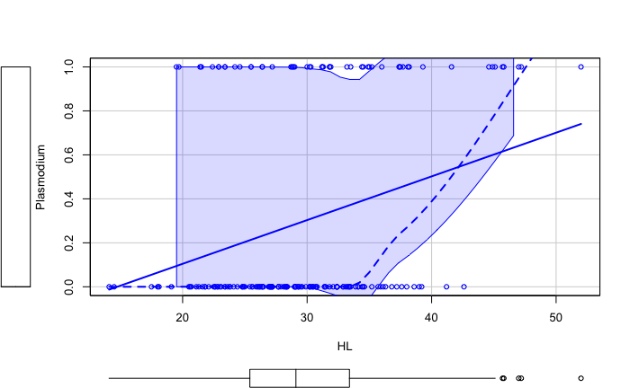

```r
scatterplot(Plasmodium ~ HL, data=df)
```

#### Now fit the generalised linear model, Plasmodium = intercept + slope*HL, with a binomial response variable.

Think about how you might check how well the model fits

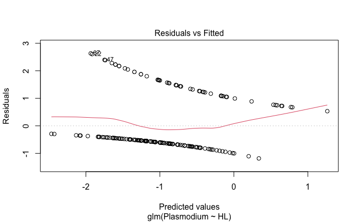

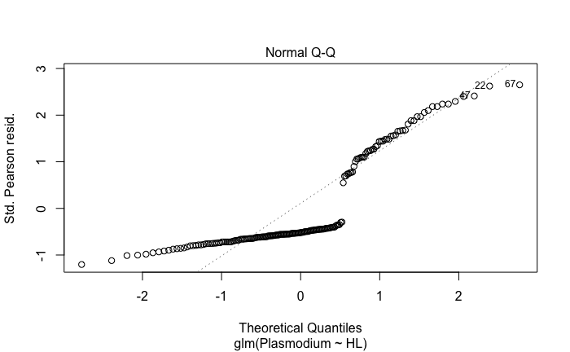

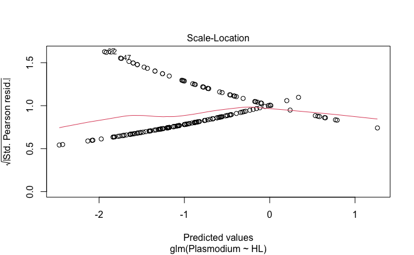

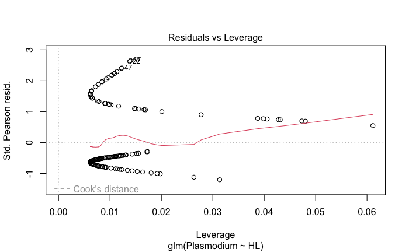

```r
townsend.glm <- glm(Plasmodium ~ HL, data=df, family = binomial)

#Always a good idea to check the residual plots
plot(townsend.glm)
```

> Quite different from a standard linear model! – but the overall trends suggest not too much ‘unbalance’ in the response.

**Examine the results from fitting the GLM and testing the null hypothesis that the slope of the response to predictor equals zero.**

Determine and interpret the following:

a. y-intercept

b. slope of the regression

c. z value for main H<sub>0</sub>

d. P-value for main H<sub>0</sub>

e. Obtain the 95% confidence intervals on the model estimates

```r
summary(townsend.glm)
```

```
Call:
glm(formula = Plasmodium ~ HL, family = binomial, data = df)

Deviance Residuals:
   Min      1Q  Median      3Q     Max
-1.324  -0.838  -0.688   1.048   2.035

Coefficients:
            Estimate Std. Error z value Pr(>|z|)
(Intercept)  -3.8537     0.8602   -4.48  7.5e-06 ***
HL            0.0984     0.0272    3.62    3e-04 ***
---
Signif. codes:  0 ‘***’ 0.001 ‘**’ 0.01 ‘*’ 0.05 ‘.’ 0.1 ‘ ’ 1

(Dispersion parameter for binomial family taken to be 1)

    Null deviance: 216.79  on 177  degrees of freedom
Residual deviance: 202.18  on 176  degrees of freedom
AIC: 206.2

Number of Fisher Scoring iterations: 4
```

```r
confint(townsend.glm)
```

```
              2.5 % 97.5 %
(Intercept) -5.6265 -2.236
HL           0.0469  0.154
```

#### From the results above what conclusions would you draw about the relationship between incidence of avian malaria (Plasmodium) and the homozygosity level?

**We can actually use this model to determine what the probability of a bird having avian malaria is if its homozygosity level is 50%**

```r
predPlas<-predict.glm(townsend.glm,data.frame(HL=50),type ="response", se.fit=TRUE)
predPlas$fit
```

```
    1
0.744
```

**What is that probability?**

#### Odds

We might want to something a bit more meaningful about the relationship of homozygosity level to incidence of *Plasmodium* and express this in terms of the odds of a bird having avian malaria. Remember that the binomial model uses a logit link function so that it models the response in terms of log odds (remember the odds are the probability of having *Plasmodium* divided by the probability of not having it). To compute how the odds of a bird having *Plasmodium* varies with homozygosity level in R, us *exp(coef(townsend.glm))*. You can also generate 95% confidence intervals on these odds ratios using *exp(confint.default(townsend.glm))*

```r
exp(coef(townsend.glm))
```

```
(Intercept)          HL
     0.0212      1.1034
```

```r
exp(confint.default(townsend.glm))
```

```
              2.5 % 97.5 %
(Intercept) 0.00393  0.114
HL          1.04612  1.164
```

**What do you interpret from these results about the odds of a bird having Plasmodium as you increase the homozygosity level?** You might find it helpful to plot the data as well as examining the output

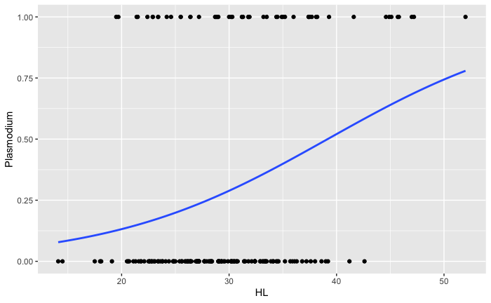

```r
ggplot(df, aes(x=HL, y=Plasmodium)) + geom_point() +
 stat_smooth(method="glm", method.args=list(family="binomial"), se=FALSE)
```

This kind of plot is quite nice here, but you might find it less helpful if your same if your sample is huge and the trend is not very clear (it’ll just look like lots of dots along two lines) . There is actually another way to show these data, which gives a nicer indication of the number of individuals with different levels of homozygosity. It uses the package *popbio* and the command *logi.hist.plot*

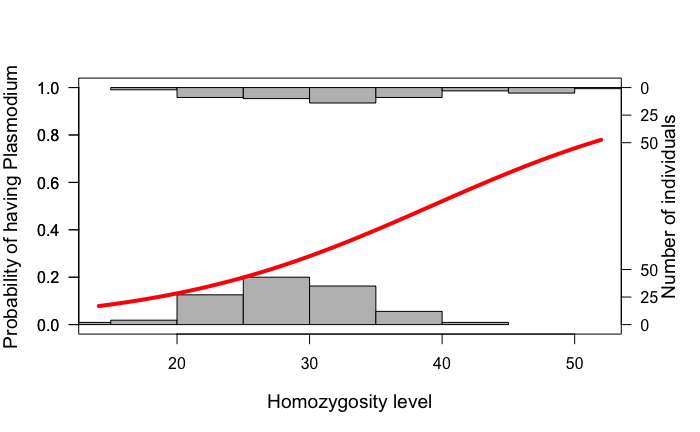

```r
install.packages("popbio")
library(popbio)
logi.hist.plot(df$HL,df$Plasmodium,boxp=FALSE,rug=FALSE,type="hist",col="grey",xlabel="Homozygosity level",ylabel="Probability of having Plasmodium",ylabel2="Number of individuals")
```

## References

Caudill SA, Rice RA (2016) Do Bird Friendly® Coffee Criteria Benefit Mammals? Assessment of Mammal Diversity in Chiapas, Mexico. *PLoS ONE* 11(11): e0165662. doi:10.1371/journal.pone.0165662

Sinclair, A. R. E. & Arcese, P. (1995). Population consequences of predation-sensitive foraging: the Serengeti wildebeeste. *Ecology*, 76, 882-91. doi.org/10.2307/1939353

Townsend, A. K., Taff, C. C., Wheeler, S. S., Weis, A. M., Hinton, M. G., Jones, M. L., Logsdon, R. M., Reisen, W. K., Freund, D., Sehgal, R. N. M., Saberi, M., Suh, Y. H., Hurd, J., and Boyce, W. M.. 2018. Low heterozygosity is associated with vector-borne disease in crows. *Ecosphere* 9( 10):e02407. 10.1002/ecs2.2407

Uefune M, Abe J, Shiojiri K, Urano S, Nagasaka K, Takabayashi J. 2020 Targeting diamondback moths in greenhouses by attracting specific native parasitoids with herbivory-induced plant volatiles. *R. Soc. Open Sci*. 7: 201592. http://dx.doi.org/10.1098/rsos.201592